# Análise de redes em psicometria, um estudo de caso

Julian Tejada

06/06/2022

# R + RStudio

O R é uma linguagem de programação para análises de dados a qual conta com diversos ambientes de desenvolvimento dentre os quais o RStudio se destaca por ser um dos mais completos. No tutorial a seguir, faremos uso de R mais RStudio para apresentar a análise de redes aplicada à psicometria usando como exemplo um banco de dados utilizado na estandardização da escala de Medo da Covid-19 (Faro et al. 202?).

## Preparação do script

Por se tratar de uma linguagem de script, o mais recomendável é começar qualquer projeto com um arquivo de script novo no qual possam ser colados os diferentes comandos. Dessa maneira sugerimos copiar cada bloco de comandos no arquivo de scritp para posteriormente testar seu funcionamento. Para começar, com o RStudio aberto, procure o menu File >> New file >> RScript, ou pressione simultaneamente as teclas Ctrl + Shitf + N.

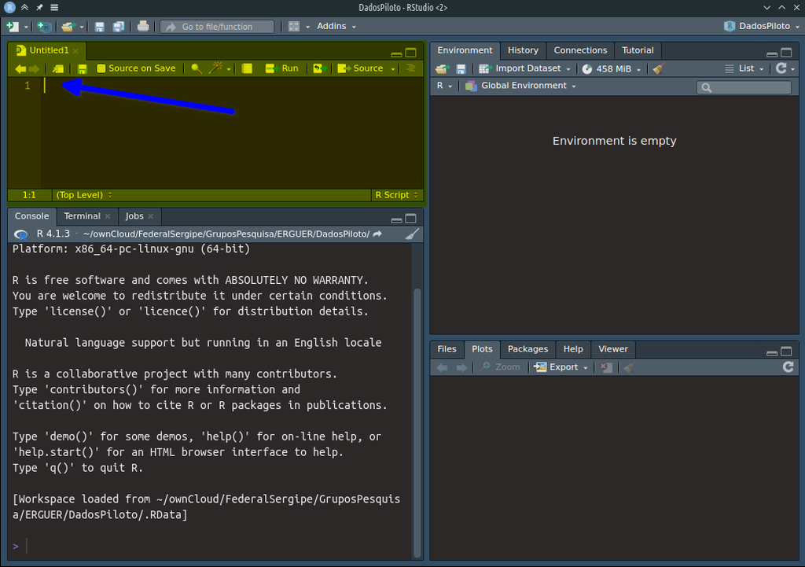

Feito isso, você encontrará, no painel superior esquerdo da janela do RStudio, uma aba chamada Untitled1 na qual deverão ser colados os comandos. Nesse mesmo painel se encontra o botão que permite a execução da linha de código na qual se encontra o cursor. Esse botão será utilizado para testar os diferentes comandos.

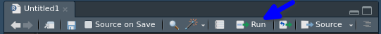

## Carregamento das bibliotecas

O R é um software de código aberto desenvolvido por uma comunidade de programadores/acadêmicos que disponibiliza seus projetos no formato de bibliotecas que devem ser instaladas e carregadas para sua utilização. Mas ao usar a combinação de R + RStudio, o processo de carregamento já envolve o processo de instalação, e cada vez que o RStudio detecte que uma nova biblioteca precisa ser carregada, ele apresentará uma mensagem perguntando se você quer instalá-la.

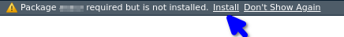

Dessa maneira, o processo de instalação e carregamento se reduz a listar a bibliotecas que usaremos na análise de redes, que no caso são:

```r
library(bootnet)
library(NetworkComparisonTest)
library(ppcor)
library(readr)
library(ggcorrplot)
library(qgraph)
library(igraph)
library(statGraph)
library(rstatix)
```

Copie e cole o anterior bloco de código no painel superior esquerdo do RStudio, e pressione as teclas Ctrl+S para salvar o arquivo, indicando um nome e uma rota no seu computador. Esse processo é necessário para que o RStudio detecte corretamente as bibliotecas que deverão ser instaladas.

# Carregamento de arquivos no R

O carregamento dos dados no R será feito usando o comando read_csv da biblioteca readr indicando a rota completa do arquivo no computador.

```r
Dados <- read_csv('C:/Users/users1/BancoTutorial.csv')
```

Uma vez executado o comando read_csv os dados ficaram temporariamente armazenados num dataframe (o formato de tabelas do R) chamado Dados

O comando summary gera um resumo com da estrutura do data frame, listando as variáveis e seus tipos. Observe que todas as variáveis são numéricas e aparecem os valores das médias, medianas e quartis dos mesmos.

```r
summary(Dados)
```

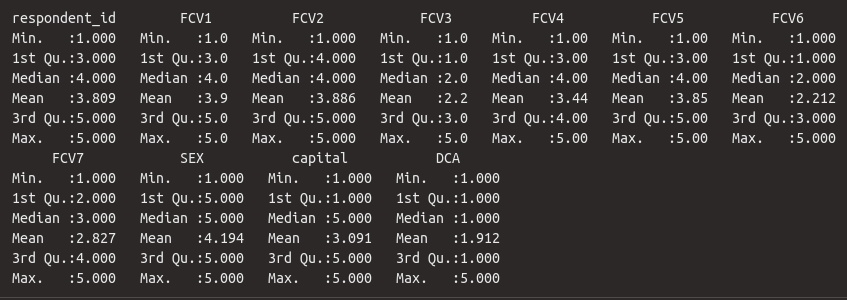

Os nomes das variáveis correspondem com a escala de: Fear of Covid-19 Scale (FCV1, FCV2, FCV3, FCV4, FCV5, FCV6, FCV7) e quatro variáveis demográficas: respondent_id (código de identificação do respondente), sexo, capital (variável dicotômica que identifica se o respondente mora ou não num centro urbano) e DCA (variável dicotômica que identifica se o participante possui alguma doença crônica diagnostica).

Uma vez identificada as variáveis do banco, o primeiro será segmentar o banco em dois, criando um novo data-frame que contenha unicamente os resultados das escalas (retirando as variáveis demográficas). Para isso usaremos o comando in que permite identificar o número das colunas que queremos retirar, para posteriormente usar o operador lógico da negação ! para indicar ao R que queremos todas as colunas do data-frame Dados excepto as colunas que não correspondem com os dados das escalas.

```r
# Cria uma lista booleana com os números das variáveis marcando as colunas que serão retiradas do banco.
cols <- names(Dados) %in% c('respondent_id', 'capital', 'DCA','SEX')
# Utiliza os índices dessa lista para retirar essas colunas e armazena o resultado na nova variável Escalas
Escalas <- Dados[!cols]
```

# Análise de rede

## Teste de correlação

As análises de redes estão baseadas em tabelas de correlações, por esse motivo, sugerimos começar a análise observando os resultados das correlações entre os diferentes itens da escala. Para isso usaremos os comandos cor_auto para estimar os valores de correlação usando o parâmetro forcePD = TRUE para checar se a matriz de correlação é estritamente positiva. Adicionalmente, usaremos o comando cor_pmat para estimar a significância das correlações, e finalmente, faremos uma visualização dos resultados usando o comando ggcorrplot.

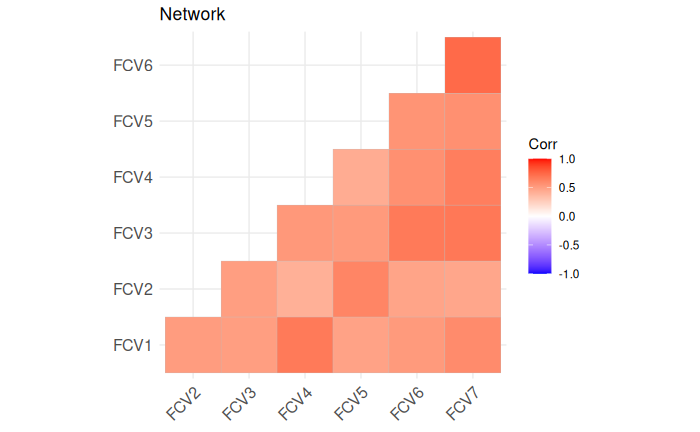

```r
# Estima as correlações
corMat <- cor_auto(Escalas,  forcePD = TRUE)
# Estima os valores de significância das correlações
p.mat <- cor_pmat(Escalas)
# Cria uma visualização dos resultados das correlações
ggcorrplot(corMat, hc.order = FALSE,
                 type = "lower", p.mat = p.mat, title = "Network")
```

A partir dos resultados das correlações, é de se esperar uma rede com nós fortemente conectados, pois houve correlações positivas entre todos os itens da escala.

## Construção da rede

O seguinte passo é construir uma rede usando como critério de limiar dos valores de correlações o EBICglasso. Para isso usaremos o comando estimateNetwork:

```r
# Construi uma rede usando o critério EBICglasso
NetworkT<- estimateNetwork(Escalas, default = "EBICglasso", threshold=TRUE)
```

## Visualização da rede

Um dos aspectos mais importantes da análise de redes é a possibilidade de visualizar as relações entre os itens construindo grafos a partir das matrizes de adjacência, nos quais cada nó representa um item e as arestas entre eles uma correlação. Para comparar visualmente o resultado do comando estimateNetwork, plotaremos a rede resultante da matriz de correlações, usando o comando qgraph, e a rede resultante do comando estimateNetwork, usando o comandoplot.

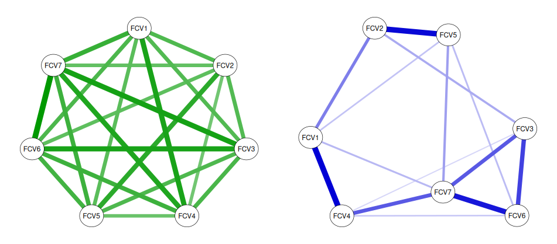

```r
# Inicializa o gerador de números aleatórios, Definindo a semente
set.seed(123)
# Divide a visualição em dois para plotar ambas redes lado a lado
par(mfrow=c(1,2))
# plora a rede a partir das matrizes de correlações
qgraph(corMat)
# Plota a rede retirando relações espúrias usando o EBICglasso
plot(NetworkT)
```

Um outro aspecto importante relacionado com a visualização é que a posição dos nós é arbitrária e não representa, em princípio, nenhuma propriedade da rede. O algoritmo estimateNetwork utilizado na construção da rede define a posição dos nós seguindo um layout baseado na força das conexões denominado “spring”, o qual utiliza, além da força das conexões, parâmetros aleatórios para definir a posição final dos nós. Dessa maneira, mudando a semente de números aleatórios, mudaram as posições dos nós.

```r
# Inicializa o gerador de números aleatórios, Definindo a semente
set.seed(456)
# Plota a rede retirando relações espúrias usando o EBICglasso
plot(NetworkT)
```

[output not shown]

### Detecção de comunidades

Na análise de redes é possível identificar grupos densamente conetados usando diferentes medidas, como por exemplo, a intermediação (edge betweenness), ou a propagação das etiquetas.

Para criar esse tipo de visualização é preciso usar a biblioteca igraph criando uma nova versão da rede a partir da matriz de adjacência que foi gerada ao usar o comando estimateNetwork, para o qual usaremos o comando graph_from_adjacency_matrix que cria a nova versão da rede, e o comando layout.fruchterman.reingold para fixar a posição dos nodos.

```r
# Cria uma versão igraph da rede
NetworkIg <- graph_from_adjacency_matrix(getWmat(NetworkT), weighted = TRUE, mode="max")
# Fixa a posição dos nodos
LayoutNetWork <- layout.fruchterman.reingold(NetworkIg)
```

Com essa nova versão da rede, calcularemos o agrupamento baseado na intermediação ou na propagação das etiquetas usando os comandos cluster_edge_betweenness ou cluster_label_prop respectivamente.

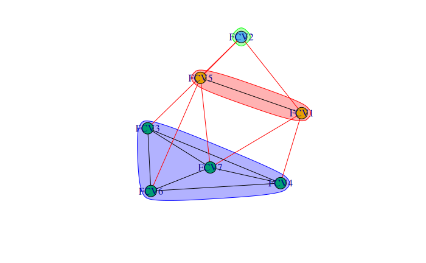

```r
# Detecção de comunidades baseada na intermediação
cebNetworkIg <- cluster_edge_betweenness(NetworkIg)
# Plotagem das comunidades
plot(cebNetworkIg, NetworkIg, layout=LayoutNetWork)
```

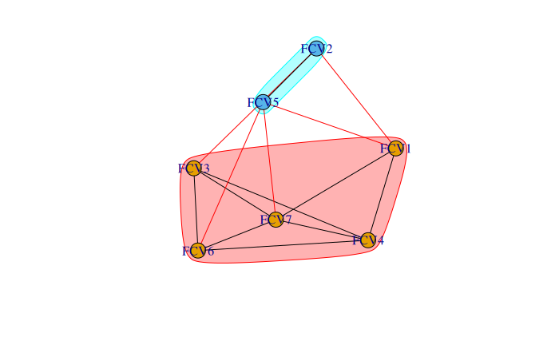

```r
# Detecção de comunidades baseada na propagação das etiquetas
clpNetworkIg <- cluster_label_prop(NetworkIg)
# Plotagem das comunidades
plot(clpNetworkIg, NetworkIg, layout=LayoutNetWork)
```

Como é possível observar, os maiores agrupamentos permanecem constantes em ambas estimações de comunidades, com pequenas alterações ao interior de alguns dos grupos, indicando que ao interior dessas comunidades há relações mais fortes entre alguns nós, como por exemplo a comunidade conformada pelos itens FCC5 e FCV1 detectada pelo método da intermediação fica subdividida na análise de propagação das etiquetas.

Finalmente, para facilitar a comparação entre o modelo de rede gerado pelo comando estimateNetwork e as visualizações geradas nas análises de comunidades, é possível voltar a plotar a rede original usando o parâmetro layout= indicando o layout extraído para fixar a posição dos nós nas análises de comunidades.

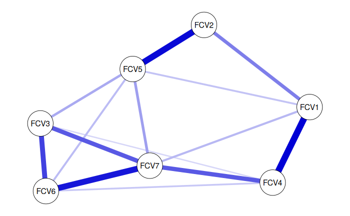

```r
# plotagem da rede original com as posições dos nós fixas
plot(NetworkT, layout=LayoutNetWork)
```

O novo resultado reposiciona os nós conforme o novo layout, mas dado que a posição espacial dos nós não tem nenhum significado, é possível reposicionar qualquer um deles para ajustar a visualização. Por exemplo, podemos reposicionar o nó FCV7 para que não obstrua a visualização da aresta entre FCV3 e FCV4.

Para mudar a posição desse nó, o primeiro que precisamos saber é qual é seu número de identificação (ID) usando o comando V()

```r
# Lista os números de identificação dos nós
V(NetworkIg)
```

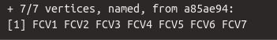

Com o resultado é possível identificar que o número do nó FCV7 é o 7, por ser o sétimo da lista. Dessa maneira, para mudar a sua posição devemos mudar as coordenadas que aparecem na variável LayoutNetWork na posição 7. Para isso usaremos a notação de variáveis de R mudando as coordenadas x e y do nó. O valor original dessas coordenadas é x=89.75885 e y=79.32442, de tal maneira que podemos reposicionar deslocando para esquerda colocando um valor menor que o valor que originalmente tinha essa coordenada:

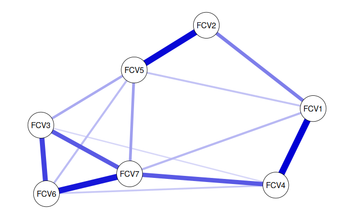

```r
# Muda a coordenada x do nó FCV7
LayoutNetWork[7,1] <- 89.5
# Muda a coordenada y do nó FCV7
LayoutNetWork[7,2] <- 79.2
# Gera novamente o grafo com o layout fixo
plot(NetworkT, layout=LayoutNetWork)
```

Ao observar a nova versão do grafo da rede uma vez reposicionado o nó FCV7 é possível identificar melhor a aresta entre FCV3 e FCV4. E como a mudança foi feita na variável LayoutNetWork, essa mudança pode ser visualizada também nas outras representações, como por exemplo, a representação das comunidades por intermediação

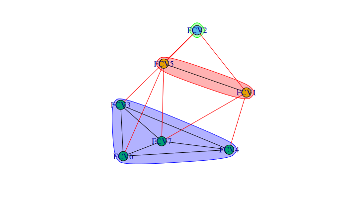

```r
# plotagem das comunidades
plot(cebNetworkIg, NetworkIg, layout=LayoutNetWork)
```

### Força da rede

Seguindo com a análise de rede o seguinte passo é estimar a força de cada nó, usando o comando centralityPlot

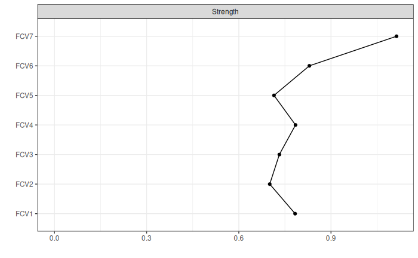

```r
# Estima a força de cada nó dentro da rede
centralityPlot(NetworkT)
```

Na figura é possível identificar o nó com mais força (FCV7) e os mais fracos (FCV2 e FCV5) que representam os nós com as correlações mais altas e mais baixas respectivamente.

### Precisão da rede

A precisão da rede é avaliada usando o procedimento de bootstrapping no qual são realizadas repetidas amostras do banco de dados, retirando de forma aleatório alguns participantes e estimando novamente todos os parâmetros da rede. Esse procedimento é repetido muitas vezes (1000 vezes ou mais) e com os resultados de cada rede são estimados intervalos de confiança dos diferentes índices de centralidade.

O comando para realizar o procedimento de bootstrapping é bootnet e o iremos parametrizar indicando o número de repetições nBoots = 1000, o número de núcleos do processador que usaremos no procedimento nCores=4 e o parâmetro type=“case” para avaliar a estabilidade da rede. Mas por se tratar de um procedimento que envolve a geração de número aleatório, o primeiro passo será definir um valor para a semente de tal maneira que possa ser possível reproduzir os mesmos resultados em outra ocasião.

```r
# Define a semente dos número aleatórios
set.seed(123)
# Realiza o procedimento de bootstrapping com 1000 repetições
boot1 <- bootnet(NetworkT, nBoots = 1000, nCores=4, type="case")
```

### Estabilidade da rede

A avaliação da estabilidade da força dos nós ao longo das amostragens é feita através da visualização dos resultados do bootstrapping com o comando:

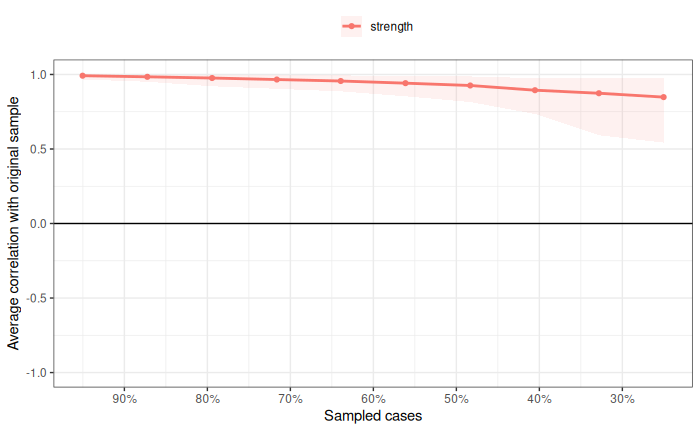

```r
# Visualização do resultado do bootstrapping
plot(boot1)
```

Como é de se esperar, a similaridade entre a rede completa e as diferentes redes construídas a partir das subamostras (procedimento de bootstrapping) decai proporcionalmente ao tamanho da amostra, não obstante, para amostras que contenham 80% ou 70% dos dados originais os resultados foram muito similares.

### Avaliação das diferenças significativas entre amostras

Para avaliar as diferenças significativas entre a força das arestas estimadas nas diferentes amostras do bootstrapping é preciso repetir novamente o comando bootnet mas retirando o parâmetro final.

```r
# Realiza novamente o procedimento de bootstrapping com 1000 repetições
boot2 <- bootnet(NetworkT, nBoots = 1000, nCores=4)
```

Uma vez repetido o procedimento de bootstrapping é possível visualizar o resultado usando o comando

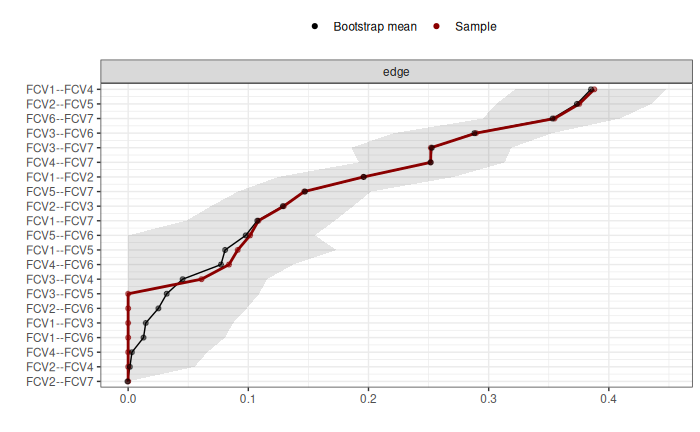

```r
# Visualização do resultado do bootstrapping
plot(boot2, labels = TRUE , order = "sample" )
```

Essa figura representa a diferença entre os valores estimados através do método de bootstrapping e os valores observados. Os valores da força de cada possível aresta são ordenados de forma crescente no eixo y, de tal maneira que é possível observar que somente um pequeno grupo de arestas apresenta valores iguais a 0 tanto na rede completa quanto nas diferentes amostras (valores que se concentram na parte inferior da figura). Ao comparar esses valores, é possível identificar uma pequena diferença nos valores dos pesos das arestas FCV1–FCV6, FCV1–FCV3 e FCV2–FCV6, que são arestas que não estão presentes na rede original mas que possivelmente apareceram em algumas das amostras obtidas através do método de bootstrapping. Mas os pesos dessas arestas incluem, nos seus intervalos de confiança, os valores de 0, o que permite afirmar que mesmo para esses casos a rede completa é precisa.

Outra maneira de visualizar as diferenças entre os pesos das arestas encontrados nas amostras do procedimento de bootstrapping é através do comando plot como parametrizado a seguir.

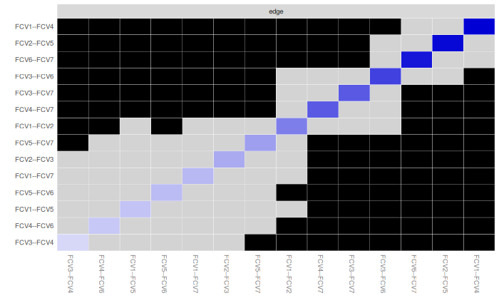

```r
# Visualização do resultado do bootstrapping
plot(boot2, statistics = "edge", plot = "difference",
           onlyNonZero = TRUE, order = "sample")
```

Adicionalmente, é possível também visualizar as diferenças significativas na força dos nós usando o comando a seguir:

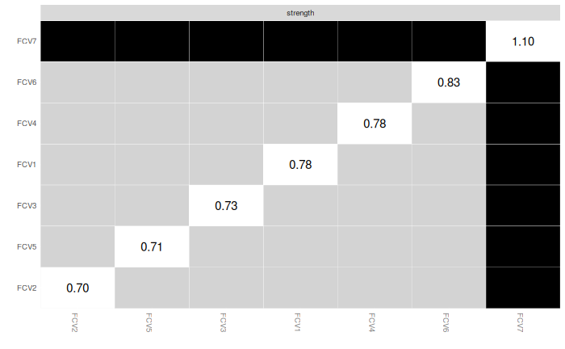

```r
# Visualização do resultado do bootstrapping
plot(boot2, "strength", order = "sample")
```

A comparação da força dos nós ao longo do procedimento de bootstrapping segue uma lógica similar da interpretação da figura anterior, onde os quadrados cinza representam que não foram encontradas diferenças significativas nos valores da força dos nós entre as amostras, e como é de esperar, a força dos nós só apresenta diferenças significativas para o nó mais forte FCV7. Os outros nós não apresentaram diferenças significativas ao longo das diferentes amostragem do procedimento de bootstrapping.

#### Coeficiente de estabilidade

Adicionalmente é possível estimar um coeficiente de estabilidade da rede usando o comando corStability

```r
# Coeficiente de estabilidade da rede
corStability(boot1)
```

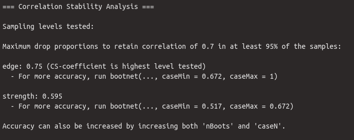

Esse coeficiente apresenta valores acima de 0,5 o que sugere que tanto a força dos nós quanto o peso das arestas pode ser corretamente interpretado pois há estabilidade entre as amostras do procedimento de bootstrapping.

# Comparações entre redes

Uma das vantagens das análises de redes é que oferecem diferentes métricas para comparar a estrutura resultante das redes, de tal maneira que possa se ter uma medida de que tão equivalente são duas redes, para dessa maneira comparar seja dois momentos diferentes ou duas populações diferentes nas quais tenha sido aplicado um instrumento.

No presente tutorial exploraremos essa comparação a partir das duas variáveis dicotômicas presentes no banco, a variável capital (variável dicotômica que identifica se o respondente mora ou não na capital) e a variável DCA (variável dicotômica que identifica se o participante possui alguma doença crônica diagnostica).

```r
# Divisão do banco a partir do local onde moram os participantes
Capital <- subset(Dados, capital==1, select=-c(SEX, respondent_id, capital, DCA))
Interior <- subset(Dados, capital==5, select=-c(SEX, respondent_id, capital, DCA))
```

Um procedimento similar será feito para dividir o banco entre aquelas pessoas que reportaram ou não possuir alguma doença crônica diagnosticada.

```r
# Divisão do banco a partir do local onde moram os participantes
SemDCA <- subset(Dados, DCA==1, select=-c(SEX, respondent_id, capital, DCA))
ComDCA <- subset(Dados, DCA==5, select=-c(SEX, respondent_id, capital, DCA))
```

Uma vez divididos os bancos procedemos a construír a rede usando o comando estimateNetwork

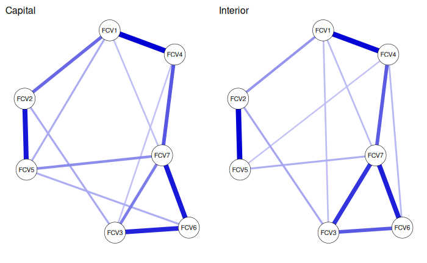

```r
# Cria as duas redes a partir dos bancos da variável capital
NetworkCapital <- estimateNetwork(Capital, default = "EBICglasso", threshold=TRUE)
NetworkInterior <- estimateNetwork(Interior, default = "EBICglasso", threshold=TRUE)
# Cria uma visualização das redes estimando inicialmente um layout médio
LayoutCapital <- averageLayout(NetworkCapital, NetworkInterior, layout = "spring", repulsion = 1)
# Divide a figura em dois para posicionar lado a lado as redes
par(mfrow=c(1,2))
# Plota cada rede
plot(NetworkCapital, layout = LayoutCapital, title="Capital")
plot(NetworkInterior, layout = LayoutCapital, title="Interior")
```

Ao inspecionar visualmente as redes resultantes é possível identificar diferenças nas arestas presentes em cada rede. Por exemplo, as arestas entre FCV5–FCV6 está presentes na rede dos dados das pessoas que moram na capital mas ausentes na rede das pessoas que moram no interior, e a aresta entre FCV4 e FCV5 está presente na rede Interior mas ausente na rede Capital.

Por outro lado, a força dos nós apresenta padrões diferentes entre as diferentes redes, com nós mais fracos na rede Interior, como é possível observar através da figura da centralidade gerada com o comando centralityPlot

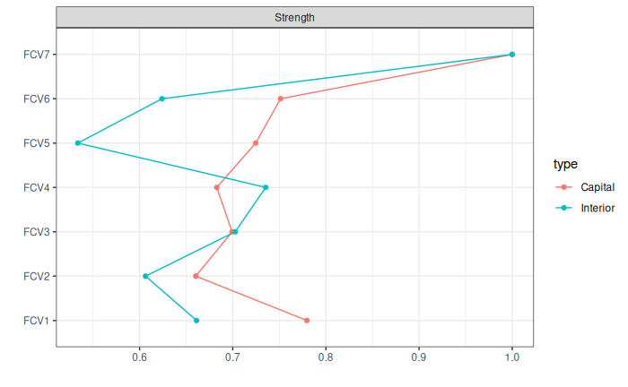

```r
# Compara a força dos nós nas duas redes
centralityPlot(list(Capital=NetworkCapital, Interior=NetworkInterior), scale="relative")
```

Essas diferenças nos valores dos pesos dos nós apresentada na figura anterior foram identificadas como sendo significativas quando comparadas as redes com o comando NTC

```r
# Compara as redes
NCT(NetworkCapital, NetworkInterior,it=200, binary.data=FALSE, paired=FALSE, weighted=TRUE)
```

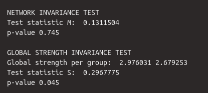

O resultado da comparação permite afirmar que no que se refere a estrutura das redes elas podem ser consideradas invariantes, mas no que se refere aos pesos dos nós, as redes são diferentes. Em outras palavras, as conexões entre as duas redes são mais ou menos as mesmas, mas os pesos dos nós são diferentes.

Uma análise similar, mas considerando agora o fato de possuir ou não uma doença crônica diagnosticada, pode ser feito usando a sequencia de comandos a seguir

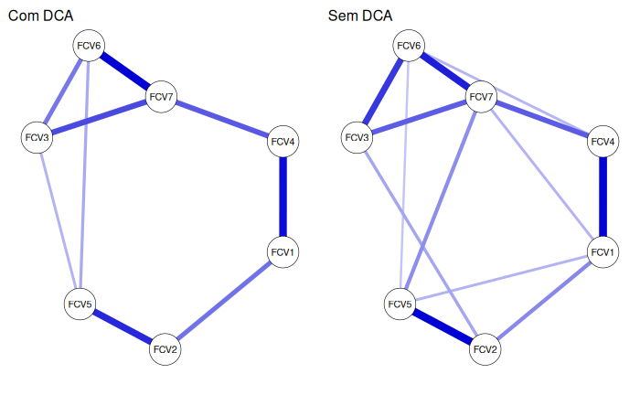

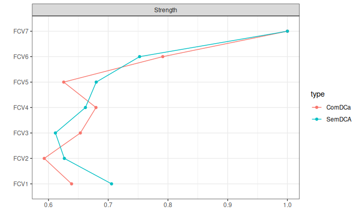

```r
# Cria as duas redes a partir dos bancos da variável capital
NetworkComDCA <- estimateNetwork(ComDCA, default = "EBICglasso", threshold=TRUE)
NetworkSemDCA <- estimateNetwork(SemDCA, default = "EBICglasso", threshold=TRUE)
# Cria uma visualização das redes estimando inicialmente um layout médio
LayoutDCA <- averageLayout(NetworkComDCA, NetworkSemDCA, layout = "spring", repulsion = 1)
# Divide a figura em dois para posicionar lado a lado as redes
par(mfrow=c(1,2))
# Plota cada rede
plot(NetworkComDCA, layout = LayoutDCA, title="Com DCA")
plot(NetworkSemDCA, layout = LayoutDCA, title="Sem DCA")
# Compara a força dos nós nas duas redes
centralityPlot(list(ComDCa=NetworkComDCA, SemDCA=NetworkSemDCA), scale="relative")
# Compara as redes
NCT(NetworkComDCA, NetworkSemDCA, it=200, binary.data=FALSE, paired=FALSE, weighted=TRUE)
```

As redes resultantes da divisão do banco considerando o fato de possuir ou não uma doença crônica diagnosticada apresentam diferenças no número de arestas e na força dos nós, não obstante, ao executar o comando NTC é possível afirmar que essas redes não são significativamente diferentes nem na sua estrutura nem na força dos nós.

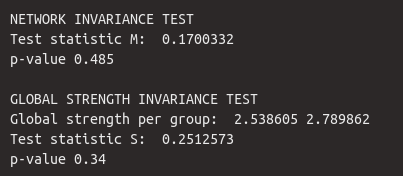

### Análise de entropia

Uma outra maneira de comparar as redes é através de uma medida de entropia que avalia que tão desorganizada é a estrutura de uma rede, o que permite supor que se a entropia em uma rede é muito maior que em outra, as interações entre os diferentes elementos da rede são mais desorganizados. O

O cálculo da entropia é feito usando o comando graph.entropy da biblioteca statGraph, e versões igraph das redes

```r
# Cria versões igraph das redes
NetworkCapitalIg <- graph_from_adjacency_matrix(getWmat(NetworkCapital), weighted = TRUE, mode="max")
NetworkInteriorIg <- graph_from_adjacency_matrix(getWmat(NetworkInterior), weighted = TRUE, mode="max")

# Estima entropia para cada uma das redes
graph.entropy(NetworkCapitalIg)
graph.entropy(NetworkInteriorIg)
```

[output not shown]

A entropia da rede Urbana é um pouco maior que a rede Interior, o que pode sugerir processos psicológicos mais complexos em ambientes urbanos, não obstante, as diferenças desses valores são muito pequenas para que possam ser interpretáveis.

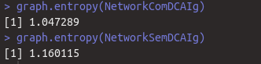

```r
# Cria versões igraph das redes
NetworkComDCAIg <- graph_from_adjacency_matrix(getWmat(NetworkComDCA), weighted = TRUE, mode="max")
NetworkSemDCAIg <- graph_from_adjacency_matrix(getWmat(NetworkSemDCA), weighted = TRUE, mode="max")

# Estima entropia para cada uma das redes
graph.entropy(NetworkComDCAIg)
graph.entropy(NetworkSemDCAIg)
```